# Управление журналами событий в системе

Майоров Дмитрий Андреевич

# Информация

## Докладчик

- Майоров Дмитрий Андреевич >

# Цель работы

Получить навыки работы с журналами мониторинга различных событий в системе

# Выполнение лабораторной работы

Открываем три вкладки терминала и в каждом из них получаем полномочия администратора

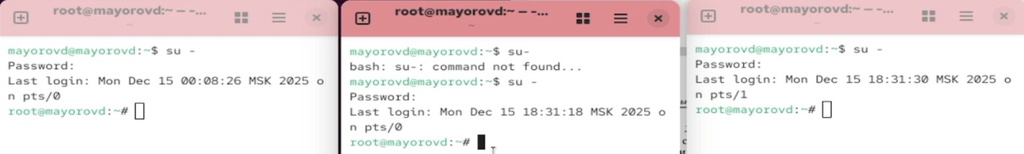

Рисунок 1

# Выполнение лабораторной работы

Во второй вкладке терминала запускаем мониторинг системных чобытий в реальном времени

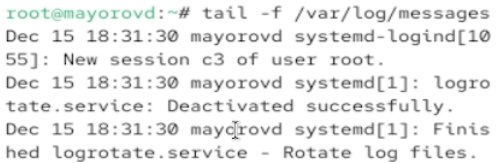

Рисунок 2

# Выполнение лабораторной работы

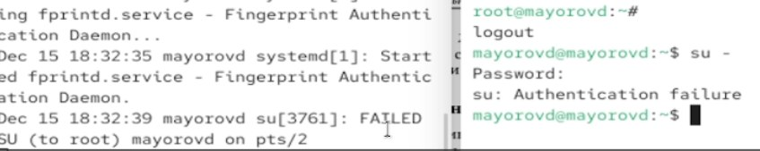

Рисунок 3

# Выполнение лабораторной работы

В третьей вкладке терминала вводим logger hello. В мониторинге событий видим сообщение “hello”

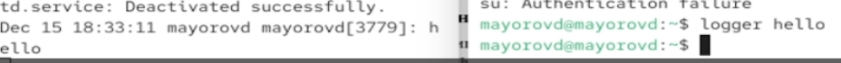

Рисунок 4

# Выполнение лабораторной работы

С помощью ctrl+c останавливаем трассировку файла сообщений мониторинга в реальном времени и запускаем мониторинг сообщений безопастности

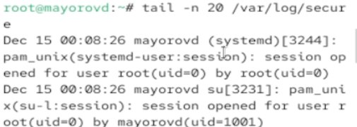

Рисунок 5

# Выполнение лабораторной работы

Устанавливаем Apache

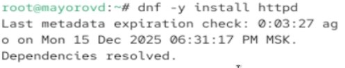

Рисунок 6

# Выполнение лабораторной работы

Запускаем веб службу

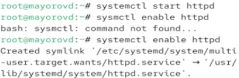

Рисунок 7

# Выполнение лабораторной работы

Во второй вкладке терминала смотрим журнал сообщений об ошибках веб-службы

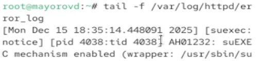

Рисунок 8

# Выполнение лабораторной работы

В третьей вкладке терминала получаем полномочия администратора и в файле конфигурации /etc/httpd/conf/httpd.conf в конце добавляем следующую строку: ErrorLog syslog:local1

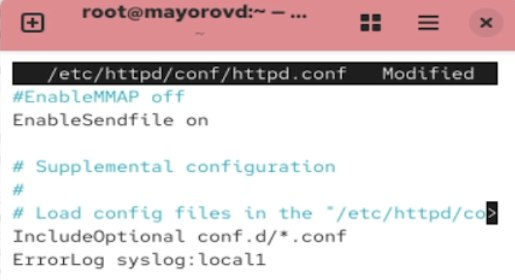

Рисунок 9

# Выполнение лабораторной работы

Переходим в каталог etc/rsyslog.d и создаем там файл мониторинга событий веб-службы

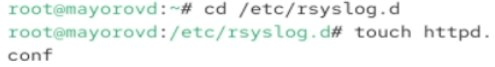

Рисунок 10

# Выполнение лабораторной работы

Открываем файл на редактирование и прописываем в нем local1.* -/var/log/httpd-error.log.

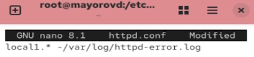

Рисунок 11

# Выполнение лабораторной работы

В первой вкладке терминала перезагружаем веб-службу и конфигурацию rsyslogd

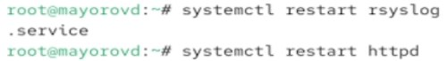

Рисунок 12

# Выполнение лабораторной работы

В третьей вкладке терминала создаем файл конфигурации для мониторинга отладочной информации и вводим следующую команду

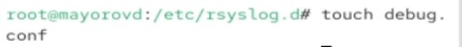

Рисунок 13

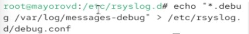

Рисунок 14

# Выполнение лабораторной работы

В первой вкладке терминала перезагружаем rsylogd

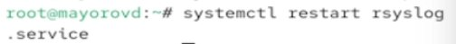

Рисунок 15

# Выполнение лабораторной работы

Во второй вкладке терминала запускаем мониторинг отладочной информации

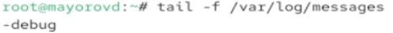

Рисунок 16

# Выполнение лабораторной работы

В третьей вкладке терминала вводим следующую команду. Смотрим в мониторинге сообщение отладки. Закрываем трассировку с помощью ctrl+c

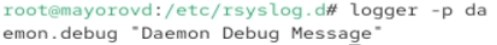

Рисунок 17

# Выполнение лабораторной работы

Во второй вкладке терминала используем journalctl для просмотра журнала содержимого с событиями с момента послднего запуска системы

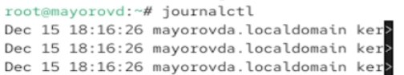

Рисунок 18

# Выполнение лабораторной работы

# Выполнение лабораторной работы

Смотрим события для UID0, последние 20 строк журнала и сообщения об ошибках

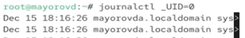

Рисунок 21

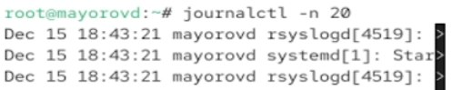

Рисунок 22

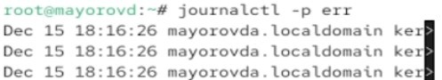

Рисунок 23